# Project Python Foundations: FoodHub Data Analysis

# Q12.5b Observation - `cuisine_type` by `cost_of_the_order`

- This plot looks similar to the univariate count plot for cuisine type (See 6.5a)
- The cuisine types that bring in the most sales are: American, Japanese, Italian, and Chinese
  - This is the same top 4 when measured by order count

# Q12.5c - Sales of cuisine by day of the week?

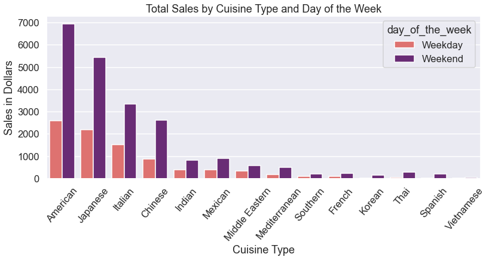

```python
# How is the total order sales distributed by cuisine type and day of the week?

# Group by cuisine and day of the week, then summarize costs
wsum = df.groupby(['cuisine_type','day_of_the_week'])['cost_of_the_order'].sum().reset_index()

# Rename cost column to sales
wsum.rename(columns = {'cost_of_the_order':'sales'}, inplace = True)

# Bar plot
plt.figure(figsize=(13, 5))
sns.barplot(data=wsum,
            x='cuisine_type',
            y='sales',
            hue='day_of_the_week',
            palette='magma_r',
            order = ratings['cuisine_type'].value_counts().index)
plt.xticks(rotation=50)
plt.title("Total Sales by Cuisine Type and Day of the Week")
plt.ylabel("Sales in Dollars")
plt.xlabel("Cuisine Type")
plt.savefig("sales_cuisine_day.jpg", bbox_inches='tight')
```

# Q12.5c Observations - `cost_of_the_order`, `cuisine_type`, and `day_of_the_week`

- This plot makes it more obvious how the less popular cuisine types are affected by day of the week
- Korean, Thai, Spanish, and Vietnamese generate negligible sales on week days

# Q12.6a - What is the spread of restaurants by cuisine type?

```python
# How many restaurants are in each cuisine category?

df.groupby('cuisine_type')['restaurant_name'].nunique().sort_values(ascending=False)
```

```
cuisine_type
American          41
Italian           31
Japanese          29
Chinese           16
Indian            14
Mexican           11
Thai               9
Middle Eastern     7
Korean             5
Mediterranean      5
French             3
Spanish            3
Vietnamese         3
Southern           2
Name: restaurant_name, dtype: int64
```

# Q12.6a Observations - `restaurant_name` by `cuisine_type`

- By number of unique restaurants, the top 4 cuisine types are American, Italian, Japanese, and Chinese
  - The same top 4 we've seen before
- Is NYC saturated with American restaurants or are American restaurants more likely to register with FoodHub?

# Q12.6b - Most popular restaurants in each cuisine type?

```python
# What are the top 3 restaurants in each cuisine type?

# Group the data and count
qui = df.groupby(['cuisine_type','restaurant_name'])['order_id'].count().reset_index().dropna()
qui = qui.sort_values(by=['cuisine_type','order_id'], ascending=(True,False)).reset_index(drop=True)


# Print the top 3 rows of each cuisine type
for i in qui['cuisine_type'].unique():
    top = qui[qui['cuisine_type']==i]['restaurant_name'].tolist()
    print(i, top[0:3])
```

```
American ['Shake Shack', 'Blue Ribbon Fried Chicken', 'Five Guys Burgers and Fries']
Chinese ['RedFarm Broadway', 'RedFarm Hudson', 'Han Dynasty']
French ['Balthazar Boulangerie', "L'Express", 'Le Grainne Cafe']
Indian ['Tamarind TriBeCa', 'The Kati Roll Company', 'Junoon']
Italian ['The Meatball Shop', 'Parm', 'Rubirosa']
Japanese ['Blue Ribbon Sushi', 'TAO', 'Blue Ribbon Sushi Bar & Grill']
Korean ['Cho Dang Gol', "Don's Bogam BBQ & Wine Bar", 'Hangawi']
Mediterranean ["Jack's Wife Freda", "Mamoun's Falafel", 'Barbounia']
Mexican ['Chipotle Mexican Grill $1.99 Delivery', 'Cafe Habana', 'Empanada Mama (closed)']
Middle Eastern ['Cafe Mogador', 'ilili Restaurant', '12 Chairs']
Southern ['Hill Country Fried Chicken', "Amy Ruth's", "'wichcraft"]
Spanish ['Boqueria', 'DespaÌ±a', 'Socarrat Paella Bar']
Thai ['Lantern Thai Kitchen', 'Pinto Nouveau Thai Bistro', 'Room Service']
Vietnamese ['V-Nam Cafe', 'Xe May Sandwich Shop', 'Nha Trang One']
```

# Q12.6b Observation - `cuisine_type` and `restaurant_name`

- These lists could be used to entice customers to try new cuisine types
  - For example:
    - While a customer is looking at popular Japanese restaurants, the FoodHub app could suggest the top restaurants in Korean and Vietnamese
- What about the top 3 rated restaurants per cuisine type?

# Q12.7 Is cost of the order related to day of the week?

```
Weekday mean:  16.311188299817204
Weekend mean:  16.574833456698773
```

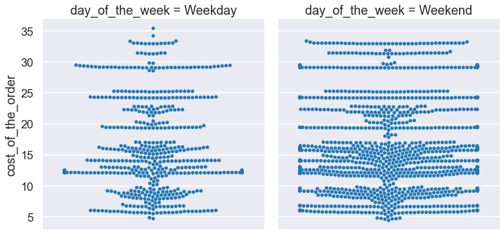

```python
# How does the cost of order compare by day of the week?

# Swarm plots
plt.figure(figsize=(13,8))
sns.catplot(data=df, y='cost_of_the_order', col='day_of_the_week', kind='swarm');

print("Weekday mean: ",df[df['day_of_the_week']=='Weekday']['cost_of_the_order'].mean())
print("Weekend mean: ",df[df['day_of_the_week']=='Weekend']['cost_of_the_order'].mean())
```

# Q12.7 Observation - `cost_of_the_order` and `day_of_the_week`

- The distributions of costs looks similar
- There are more orders on the Weekend than the Weekday
- There are slightly more higher-priced orders on Weekends too
- Weekday mean: $16.31
- Weekend mean: \$16.57

# Q12.8 - What's the distribution of cuisine types by rating?

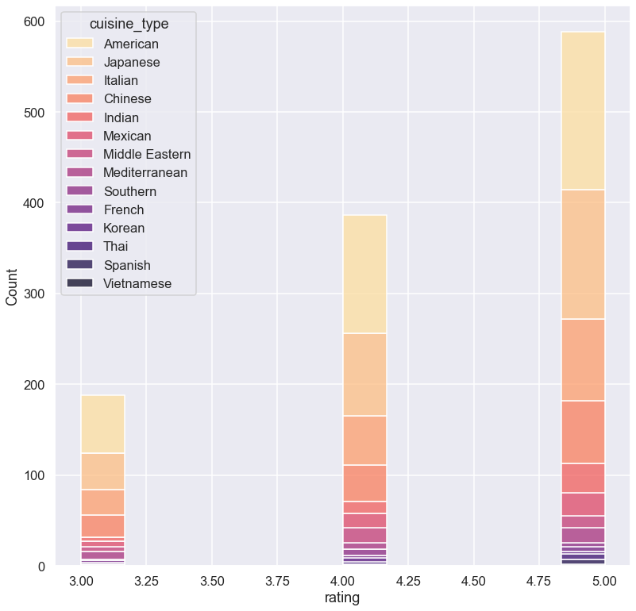

```python
# plot a histogram for rating with cuisine as stacked hue
plt.figure(figsize=(13,13))
sns.histplot(ratings,
             x='rating',
             stat='count',
             hue='cuisine_type',
             hue_order=ratings['cuisine_type'].value_counts().index,
             palette='magma_r',
             multiple='stack')
plt.savefig("rating_cuisine_count.jpg", bbox_inches='tight')
```

# Q12.8 Observation - `rating` by `cuisine_type`

- The distribution of ratings by cuisine type looks similar for all 3 columns
- As we would hope, this suggests that cuisine type has no weight on a customers' ratings

# Q12.9 - What's the average rating in each cuisine category?

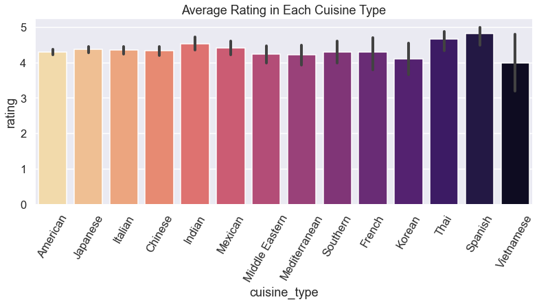

```python
# bar plot where rating is averaged

plt.figure(figsize=(13, 5))
sns.barplot(data=ratings,
            x='cuisine_type',
            y='rating',
            palette='magma_r',
            order=ratings['cuisine_type'].value_counts().index);
plt.xticks(rotation=60);
plt.title("Average Rating in Each Cuisine Type")
plt.savefig("rating_cuisine.jpg", bbox_inches='tight')
```

# Q12.9 Observation - `rating` by `cuisine_type`

- The average ratings are similar in all the different cuisine categories
- The cuisines on the far right have less data points and therefore less confidence in the mean
- However, Spanish stands out as having the highest average rating
  - Is there a Spanish restaurant that is encouraging its customers to rate them?

### Question 13: Suppose the company wants to provide a promotional offer in the advertisement of the restaurants. The condition to get the offer is that the restaurants must have a rating count of more than 50 and the average rating should be greater than 4. Write the code to find the restaurants fulfilling the criteria to get the promotional offer. (2 marks)

```python
# Use the ratings dataframe made earlier (See Question 12.3)
# ratings dataframe has all 'Not given' ratings removed


# Group by restaurant name and count the rating column
rates = ratings.groupby('restaurant_name', as_index=False)['rating'].count()

# Next, subset only those rows with a rating count greater than 50
rates = rates[rates['rating']>50]

# Extract the restaurant names as a list to be used later in the code
rlist = rates['restaurant_name'].tolist()

# Group the dataframe by restaurant names and find the mean of all ratings
means = ratings.groupby('restaurant_name', as_index=False)['rating'].mean()

# Subset only the entries where the mean of rating is greater than 4
means = means[means['rating']>4]

# Select only the 4 restaurants that have greater than 50 ratings, and sort in descending order
means[means['restaurant_name'].isin(rlist)].sort_values('rating', ascending=False).reset_index(drop=True)
```

|  | restaurant_name | rating |
| --- | --- | --- |
| 0 | The Meatball Shop | 4.511905 |
| 1 | Blue Ribbon Fried Chicken | 4.328125 |
| 2 | Shake Shack | 4.278195 |
| 3 | Blue Ribbon Sushi | 4.219178 |

# Q13 Observation:

- There are only 4 restaurants in the dataset that have more than 50 ratings
- Of those 4, they all had ratings that averaged above 4 stars
  - 'Blue Ribbon Fried Chicken', 'Blue Ribbon Sushi', 'Shake Shack', and 'The Meatball Shop'

### Question 14: Suppose the company charges the restaurant 25% on the orders having cost greater than 20 dollars and 15% on the orders having cost greater than 5 dollars. Write the code to find the net revenue generated on all the orders given in the dataset. (2 marks)

```python
# Find net revenue when (1) every order over $5 generates 15% profit, and (2) every order over $20 gets 25% profit

# create a function named f that returns the profit based on the conditions
def f(x):
    if x > 20:
        return x*.25  # 25% when >20
    elif x >5:
        return x*.15  # 15% when >5
    else:
        return 0      # no charge if under $5

# Apply the function to the costs column and save
charge = df['cost_of_the_order'].apply(f)

# Add up the charges to find the total
charge.sum()
```

```
6166.303
```

# Q14 Observations:

- From these 1898 orders, a net profit of **$6166.30** was made

### Question 15: Suppose the company wants to analyze the total time required to deliver the food. Write the code to find out the percentage of orders that have more than 60 minutes of total delivery time. (2 marks)

Note: The total delivery time is the summation of the food preparation time and delivery time.

```python
# Use the total_time column we made earlier

# Find the boolean values where total_time is greater than 60
# Take the sum of the boolean values (True = 1, False = 0) to find the count of orders over 60 min
# Then divide the sum by the total rows of the original dataset to find the percentage

LIMIT = 60
np.sum(df['total_time']>LIMIT)/df.shape[0]
```

```
0.1053740779768177
```

# Q15 Observation

- About 10.5% of all orders have greater than 60 minutes of total delivery time
- It's good to know that 9 out of 10 orders take less than an hour, and there is room for improvement

### Question 16: Suppose the company wants to analyze the delivery time of the orders on weekdays and weekends. Write the code to find the mean delivery time on weekdays and weekends. Write your observations on the results. (2 marks)

```python
# Find the average delivery times
print("Average delivery time on Weekdays:", df[df['day_of_the_week']=='Weekday']['delivery_time'].mean())
print("Average delivery time on Weekends:", df[df['day_of_the_week']=='Weekend']['delivery_time'].mean())
print()


# Find average total order times
print("Average total order time on Weekdays:", df[df['day_of_the_week']=='Weekday']['total_time'].mean())
print("Average total order time on Weekends:", df[df['day_of_the_week']=='Weekend']['total_time'].mean())
```

```
Average delivery time on Weekdays: 28.340036563071298
Average delivery time on Weekends: 22.4700222057735

Average total order time on Weekdays: 55.552102376599635
Average total order time on Weekends: 49.90673575129534
```

# Q16 Observations:

- On Weekdays, delivery times generally take longer, averaging at around 28 minutes
- On Weekends, delivery times are generally faster, averaging at around 22 minutes
- That's a 6-minute difference in averages
- The total order time also has a 6-minute difference.

### Conclusion and Recommendations

### **Question 17:** Write the conclusions and business recommendations derived from the analysis. (5 marks)

### Insights:

##### Notable Trends

- Half of all restaurants have 3 orders or less
- Only 10% of restaurants have more than 25 orders
- American cuisine is by far the most popular cuisine type, followed by Japanese
- So far, ratings given to orders doesn't seem related to any of the factors in this dataset, not even delivery time
- Orders are generally faster on weekends

##### Revenue Trends

- The company generated over \$6000 in revenue from about 2000 orders
- There is more than double the orders placed on weekends
- Only 29% of orders were over \$20
- The average order cost is \$16.50, and it isn't affected by day of the week
- The order with the highest cost was $35.41
  - It seems like most food orders serve 1 to 2 people

##### Recommendations

- More revenue can be captured if we can **increase orders placed on weekdays**
  - More drivers on the road during the week
  - Send reminders to customers who have never ordered during the middle of the week
  - Offer discounts on the slowest days of the week
- More revenue can be captured if we can **increase the average cost per order**
  - Suggest add-on menu items during the ordering process
  - Entice customers in the app to try new restaurants that have higher ticket items
  - Offer free delivery or other perks for orders over a certain amount
  - Promote "Party Trays", "Family Meals", or office lunch catering deals
- More revenue can be captured if we **increase all orders on the app**
  - Smaller charges to restaurants who refer more customers from their website to join the app
  - Customer referral bonuses (friends bring in more friends)
  - Rotating specials for repeat customers (keep them coming back)
  - Better marketing
    - Branding on driver vehicles
    - Recruit more restaurants to join the app
    - Increase app visibility by asking more customers to rate the app and leave feedback
  - Find out if there is a pattern across one-time customers
- Collect more data, explore more trends, and test more ideas

##### Questions for further consideration

- How can the customer base be categorized?
- Which restaurants have the most one-time customers?
- Which restaurants have the highest returning customers?
- Which customers have placed the most orders?
  - Of those "FoodHub Fans", do they share any similarities?
  - Do they spend more or less than the average customer?
  - Do they all order from a common shared restaurant?
  - Could they be easily enticed with additional offers?
- What about customers who have only ever ordered once on the app?
  - How many are there?
  - How much are their orders compared to the averages?
  - Did they give bad ratings?
  - Was the wait time long?
  - Are most one-time users ordering on a certain day of the week?
- What's the average sale across all restaurants?
  - Which restraurants have the highest/lowest average sales?
  - What about across weekend vs weekday?
- Which restaurants have the shortest/longest prep times?
  - Does prep time correlate with other factors, such as
    - most orders
    - highest cost
    - day of the week
    - rating
- What are the top 5 restaurants in ratings for each cuisine category?
- What are the top 5 restaurants in total sales by cuisine type?
- Who are the repeat customers and what do they have in common?
- Which repeat customers are paying the same exact cost each time?
  - This could suggest customers that stick to what's familiar and prefer a simple approach.
  - If a repeat customer is shopping around at different restaurants and always paying a different cost each order, this could suggest a customer who likes to try new things.
- Is there a picky customer out there who is giving all bad reviews?
  - How many customers give no reviews at all?
  - Are these 'Not given' reviews from repeat customers who only feel like reviewing once?
- How many orders does the average customer place?
  - For anyone on the app who has placed more than X orders, how many ratings have they given vs not given?
    - Of given, what's the average rating?
- Do repeat customers order more on the weekend vs weekday?
  - How does that compare to the average customer?